# Project Python Foundations: FoodHub Data Analysis

**Marks: 60**

### Context

The number of restaurants in New York is increasing day by day. Lots of students and busy professionals rely on those restaurants due to their hectic lifestyles. Online food delivery service is a great option for them. It provides them with good food from their favorite restaurants. A food aggregator company FoodHub offers access to multiple restaurants through a single smartphone app.

The app allows the restaurants to receive a direct online order from a customer. The app assigns a delivery person from the company to pick up the order after it is confirmed by the restaurant. The delivery person then uses the map to reach the restaurant and waits for the food package. Once the food package is handed over to the delivery person, he/she confirms the pick-up in the app and travels to the customer's location to deliver the food. The delivery person confirms the drop-off in the app after delivering the food package to the customer. The customer can rate the order in the app. The food aggregator earns money by collecting a fixed margin of the delivery order from the restaurants.

### Objective

The food aggregator company has stored the data of the different orders made by the registered customers in their online portal. They want to analyze the data to get a fair idea about the demand of different restaurants which will help them in enhancing their customer experience. Suppose you are hired as a Data Scientist in this company and the Data Science team has shared some of the key questions that need to be answered. Perform the data analysis to find answers to these questions that will help the company to improve the business.

### Data Description

The data contains the different data related to a food order. The detailed data dictionary is given below.

### Data Dictionary

- order_id: Unique ID of the order
- customer_id: ID of the customer who ordered the food
- restaurant_name: Name of the restaurant
- cuisine_type: Cuisine ordered by the customer
- cost: Cost of the order
- day_of_the_week: Indicates whether the order is placed on a weekday or weekend (The weekday is from Monday to Friday and the weekend is Saturday and Sunday)
- rating: Rating given by the customer out of 5
- food_preparation_time: Time (in minutes) taken by the restaurant to prepare the food. This is calculated by taking the difference between the timestamps of the restaurant's order confirmation and the delivery person's pick-up confirmation.
- delivery_time: Time (in minutes) taken by the delivery person to deliver the food package. This is calculated by taking the difference between the timestamps of the delivery person's pick-up confirmation and drop-off information

### Let us start by importing the required libraries

```python
# import libraries for data manipulation
import numpy as np
import pandas as pd
import random
from scipy.stats import f_oneway

# import libraries for data visualization
import matplotlib.pyplot as plt
import seaborn as sns
```

### Understanding the structure of the data

```python
# uncomment and run the following lines for Google Colab
from google.colab import drive
drive.mount('/content/drive')
```

```python
# read the data
df = pd.read_csv('/content/drive/MyDrive/foodhub_project/foodhub_order.csv')
# returns the first 5 rows
df.head()
```

|  | order_id | customer_id | restaurant_name | cuisine_type | cost_of_the_order | day_of_the_week | rating | food_preparation_time | delivery_time |
| --- | --- | --- | --- | --- | --- | --- | --- | --- | --- |
| 0 | 1477147 | 337525 | Hangawi | Korean | 30.75 | Weekend | Not given | 25 | 20 |
| 1 | 1477685 | 358141 | Blue Ribbon Sushi Izakaya | Japanese | 12.08 | Weekend | Not given | 25 | 23 |
| 2 | 1477070 | 66393 | Cafe Habana | Mexican | 12.23 | Weekday | 5 | 23 | 28 |
| 3 | 1477334 | 106968 | Blue Ribbon Fried Chicken | American | 29.20 | Weekend | 3 | 25 | 15 |
| 4 | 1478249 | 76942 | Dirty Bird to Go | American | 11.59 | Weekday | 4 | 25 | 24 |

#### Observations:

- This DataFrame contains 9 columns, as outlined in the Data Dictionary.
- Each row represents an individual order placed by a customer.

### **Question 1:** How many rows and columns are present in the data? [0.5 mark]

```python
df.shape
```

```
(1898, 9)
```

#### Observations:

- This dataset contains 1898 rows and 9 columns.

### **Question 2:** What are the datatypes of the different columns in the dataset? (The info() function can be used) [0.5 mark]

```python
# Use info() to print a concise summary of the DataFrame
df.info()
```

```
<class 'pandas.core.frame.DataFrame'>
RangeIndex: 1898 entries, 0 to 1897
Data columns (total 9 columns):
 #   Column                 Non-Null Count  Dtype
---  ------                 --------------  -----
 0   order_id               1898 non-null   int64
 1   customer_id            1898 non-null   int64
 2   restaurant_name        1898 non-null   object
 3   cuisine_type           1898 non-null   object
 4   cost_of_the_order      1898 non-null   float64
 5   day_of_the_week        1898 non-null   object
 6   rating                 1898 non-null   object
 7   food_preparation_time  1898 non-null   int64
 8   delivery_time          1898 non-null   int64
dtypes: float64(1), int64(4), object(4)
memory usage: 133.6+ KB
```

#### Observations:

This dataset contains the following data types across its columns:

- Integer columns: order_id, customer_id, food_preparation_time, and delivery time.
- Object columns: restaurant_name, cuisine_type, day_of_the_week, and rating.
- Float column: cost_of_the_order.

### **Question 3:** Are there any missing values in the data? If yes, treat them using an appropriate method. [1 mark]

```python
# Create a DataFrame to display the count and percentage of missing values for
# columns with missing data.  'df.isnull().sum()' calculates the number of
# missing values for each column, and '[df.isnull().sum() > 0]' filters for
# columns with at least one missing value.
missing_data = pd.DataFrame({
    'Count': df.isnull().sum()[df.isnull().sum() > 0],
    'Percentage': (df.isnull().sum()[df.isnull().sum() > 0] / df.shape[0]) * 100
})

# Check if the resulting DataFrame is empty.
if missing_data.empty:
    # If there is no missing data, print a message indicating so.
    print("No missing data")
else:
    # If there is missing data, display the DataFrame with the count and
    # percentage of the missing values.
    missing_data
```

```
No missing data
```

#### Observations:

- There is no missing data in the dataset. This dataset is complete and ready for analysis, with no need for imputation.

### **Question 4:** Check the statistical summary of the data. What is the minimum, average, and maximum time it takes for food to be prepared once an order is placed? [2 marks]

```python
# Calculate the minimum food preparation time across all orders.
minimum_time = df['food_preparation_time'].min()

# Calculate the average (mean) food preparation time across all orders.
average_time = df['food_preparation_time'].mean()

# Calculate the maximum food preparation time across all orders.
maximum_time = df['food_preparation_time'].max()

# Print the minimum, average, and maximum food preparation times, formatted to
# two decimal places.
print(
    f"Minimum Time: {minimum_time:.2f}\n"
    f"Average Time: {average_time:.2f}\n"
    f"Maximum Time: {maximum_time:.2f}\n"
)
```

```
Minimum Time: 20.00
Average Time: 27.37
Maximum Time: 35.00
```

#### Observations:

- The minimum food preparation time is 20 minutes.
- The average preparation time is 27.37 minutes.
- The maximum preparation time is 35 minutes.

### **Question 5:** How many orders are not rated? [1 mark]

```python
# Count the number of orders where the rating is marked as 'Not given'.
# This creates a boolean Series where each 'Not given' rating is True, and then
# sums those True values.
unrated_orders = (df['rating'] == 'Not given').sum()

# Display the total count of unrated orders.
print(f"Number of unrated orders: {unrated_orders}")
```

```
Number of unrated orders: 736
```

#### Observations:

- There are 736 orders with a rating labeled as "Not given," indicating these entries are unrated but explicitly marked as such in the dataset.

### Exploratory Data Analysis (EDA)

### **Question 6:** Explore all the variables and provide observations on their distributions. (Generally, histograms, boxplots, countplots, etc. are used for univariate exploration.) [9 marks]

```python
def show_graph(data, graph_name, column_label, color):
    """
    Display a histogram, boxplot, or countplot based on a specific graph type.

    Parameters:
    - data (Dataframe): The dataset containing the column to be plotted.
    - graph_name (str): Type of graph to display ('histogram_boxplot'
                        or 'countplot').
    - column_label (str): The name of the column to plot.
    - color (str): Color for the plot elements.
    """

    # Map column labels to titles
    title_map = {
        'order_id': "Order ID",
        'customer_id': "Customer ID",
        'restaurant_name': "Restaurant Name",
        'cuisine_type': "Cuisine Type",
        'cost_of_the_order': "Cost of the Order",
        'day_of_the_week': "Day of the Week",
        'rating': "Rating",
        'food_preparation_time': "Food Preparation Time",
        'delivery_time': "Delivery Time"
    }

    # Get the title for the specified column, or handle invalid column
    title = title_map.get(column_label, None)
    if title is None:
        print(f"Enter valid column label!")
        return

    # Display both a histogram and boxplot for the specified column
    if graph_name == 'histogram_boxplot':

        # Set up a figure with 1 row and 2 columns for the plots
        fig, (ax1, ax2) = plt.subplots(1, 2, figsize = (12, 5))

        # Plot the histogram
        sns.histplot(
            data = data,
            x = column_label,
            bins = 43,
            color = color,
            ax = ax1
        )
        ax1.set_title(f'Histogram of {title}')
        ax1.set_xlabel(title)
        ax1.set_ylabel('Frequency')

        # Plot the boxplot
        sns.boxplot(
            data = data,
            x = column_label,
            color = color,
            ax = ax2
        )
        ax2.set_title(f'Boxplot of {title}')
        ax2.set_xlabel(title)

        # Adjust layout to prevent overlap and display the plots
        plt.tight_layout()
        plt.show()

        # Calculate and print descriptive statistics for the column
        Q1 = data[column_label].quantile(0.25)  # 25th percentile
        Q2 = data[column_label].median()        # Median (50th percentile)
        Q3 = data[column_label].quantile(0.75)  # 75th percentile
        IQR = Q3 - Q1                           # Interquartile range
        upper_bound = Q3 + 1.5 * IQR            # Upper bound for outliers
        lower_bound = Q1 - 1.5 * IQR            # Lower bound for outliers

        # Print the statistical summary
        print(
            f"Details for {title}:\n"
            f"25th percentile: {Q1:.2f}\n"
            f"Median (50th percentile): {Q2:.2f}\n"
            f"75th percentile: {Q3:.2f}\n"
            f"Upper Bound: {upper_bound:.2f}\n"
            f"Lower Bound: {lower_bound:.2f}\n"
            f"Interquartile Range (IQR): {IQR:.2f}\n"
        )

    # Display a countplot for the specified column
    elif graph_name == 'countplot':
        # Set figure size for countplot
        plt.figure(figsize = (8, 5))
        sns.countplot(
            data = data,
            x = column_label,
            color = color
        )
        plt.title(f'Countplot of {title}')
        plt.ylabel('Count')
        plt.xticks(rotation = 90)
        plt.show()

    # Handle invalid graph type input
    else:
        print(
            "Please enter valid graph name: 'histogram_boxplot' or 'countplot'."
        )
        return
```

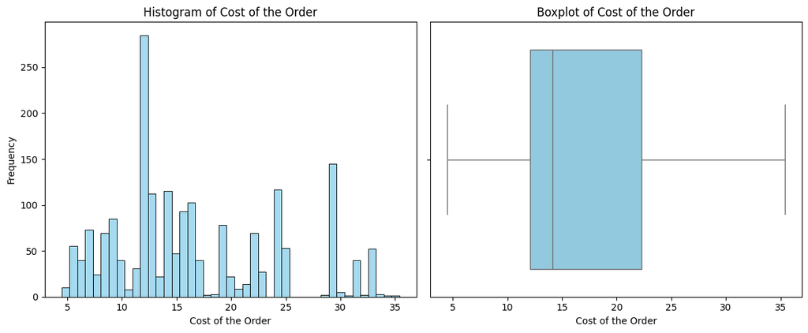

```
Details for Cost of the Order:
25th percentile: 12.08
Median (50th percentile): 14.14
75th percentile: 22.30
Upper Bound: 37.62
Lower Bound: -3.25
Interquartile Range (IQR): 10.22
```

```python
show_graph(df, 'histogram_boxplot', 'cost_of_the_order', 'skyblue')
```

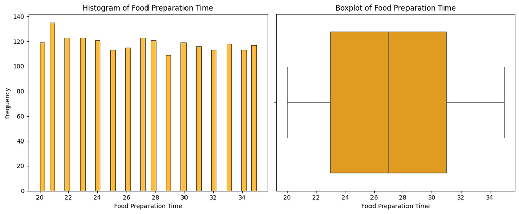

```
Details for Food Preparation Time:
25th percentile: 23.00
Median (50th percentile): 27.00
75th percentile: 31.00
Upper Bound: 43.00
Lower Bound: 11.00
Interquartile Range (IQR): 8.00
```

```python
show_graph(df, 'histogram_boxplot', 'food_preparation_time', 'orange')
```

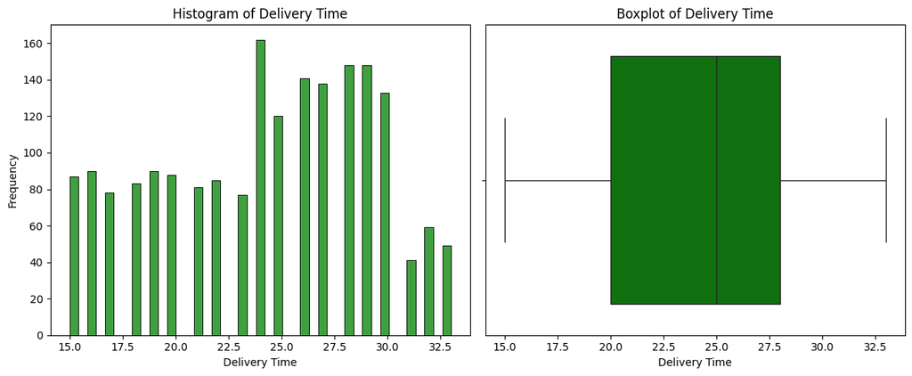

```
Details for Delivery Time:
25th percentile: 20.00
Median (50th percentile): 25.00
75th percentile: 28.00
Upper Bound: 40.00
Lower Bound: 8.00
Interquartile Range (IQR): 8.00
```

```python
show_graph(df, 'histogram_boxplot', 'delivery_time', 'green')
```

#### Observations:

- **Distribution:** The histogram shows a varied distribution with a peak around 24 minutes, suggesting this is a common delivery time.
- **Central Tendancy:** The median delivery time is 25 minutes, indicating that half of the deliveries are completed within this timeframe.
- **Variability:** The interquartile range (IQR) is 8 minutes, with the middle 50% of delivery times ranging from 20 to 28 minutes. Delivery times range from approximately 15 to 32.5 minutes, with no extreme outliers.
- **Boundaries:** The theoretical lower bound is 8 minutes, and the upper bound is 40 minutes. Actual observed delivery times fall between 15 and 32.5 minutes.

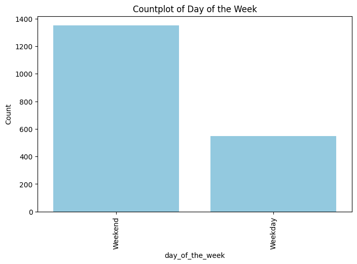

```python
show_graph(df, 'countplot', 'day_of_the_week', 'skyblue')
```

#### Observations:

- The number of orders placed on weekends are approximately double that of the orders placed on weekdays.

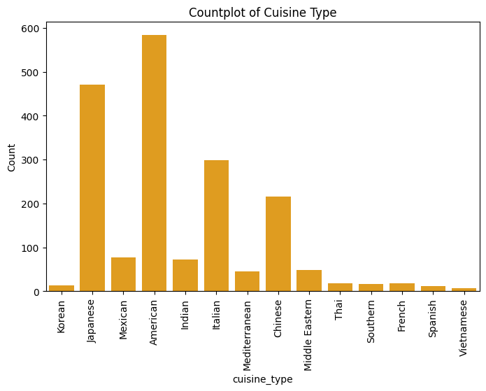

```python
show_graph(df, 'countplot', 'cuisine_type', 'orange')
```

#### Observations:

Most popular cuisines:

1. American
2. Japanese
3. Italian

Least popular cuisines:

1. Vietnamese
2. Spanish
3. Korean

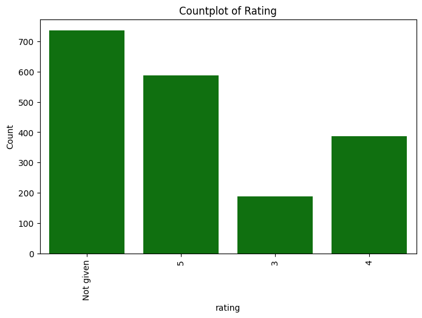

```python
show_graph(df, 'countplot', 'rating', 'green')
```

### **Question 7**: Which are the top 5 restaurants in terms of the number of orders received? [1 mark]

```python
# Identify the top 5 most frequently ordered restaurants.
# 'value_counts()' counts the occurences of each unique restaurant name,
# and 'head(5)' retrieves the top 5 with the highest order counts.
top_5_restaurants = df['restaurant_name'].value_counts().head(5)

# Display the top 5 restaurants and their respective order counts.
top_5_restaurants
```

| restaurant_name | count |
| --- | --- |
| Shake Shack | 219 |
| The Meatball Shop | 132 |
| Blue Ribbon Sushi | 119 |
| Blue Ribbon Fried Chicken | 96 |
| Parm | 68 |

**dtype:** int64

#### Observations:

The top 5 restaurants by order count are:

1. Shake Shack - 219 orders
2. The Meatball Shop - 132 orders
3. Blue Ribbon Sushi - 119 orders
4. Blue Ribbon Fried Chicken - 96 orders
5. Parm - 68 orders

### **Question 8**: Which is the most popular cuisine on weekends? [1 mark]

```python
# Filter the DataFrame for rows where 'day_of_the_week' is 'Weekend',
# then get the count of each unique 'cuisine_type' within this filtered data.
# 'value_counts()' sorts the counts in descending order, and 'head(1)' selects
# the most common cuisine.
top_weekend_cuisine = (
    df[(df['day_of_the_week']) == 'Weekend']['cuisine_type']
    .value_counts().head(1)
)

# Extract the name of the top cuisine type from the index of the results.
top_cuisine_type = top_weekend_cuisine.index[0]

# Extract the count of the top cuisine type from the result.
top_cuisine_count = top_weekend_cuisine.iloc[0]

# Print the results, showing the top cuisine type and its count on weekends.
print(
    f"Top Cuisine Type: {top_cuisine_type}\n"
    f"Top Cuisine Count: {top_cuisine_count}\n"
)
```

```
Top Cuisine Type: American
Top Cuisine Count: 415
```

#### Observations:

- The American cuisine is the most popular weekend cuisine, with 415 orders.

### **Question 9**: What percentage of the orders cost more than 20 dollars? [2 marks]

```python
# Count the number of orders with a cost greater than $20.00.
orders_gt_20 = df[(df['cost_of_the_order'] > 20.0)]['order_id'].count()

# Calculate the total number of orders.
total_orders = df['order_id'].count()

# Calculate the percentage of orders that cost more than $20.00.
percentage_orders_gt_20 = (orders_gt_20 / total_orders) * 100

# Display the percentage of orders that cost more than $20.00, rounded to two
# decimal places.
print(
    f"Percentage of orders that costs more than $20 dollars: "
    f"{round(percentage_orders_gt_20, 2)}%"
)
```

```
Percentage of orders that costs more than $20 dollars: 29.24%
```

#### Observations:

- 29.24% of the orders cost more than 20 dollars.

### **Question 10**: What is the mean order delivery time? [1 mark]

```python
# Calculate the mean (average) delivery time across all orders.
mean_delivery_time = df['delivery_time'].mean()

# Print the mean delivery time, rounded to two decimal places for readability.
print(f"Mean Delivery Time: {round(mean_delivery_time, 2)} minutes")
```

```
Mean Delivery Time: 24.16 minutes
```

#### Observations:

- The mean delivery time for orders is 24 minutes.

### **Question 11:** The company has decided to give 20% discount vouchers to the top 5 most frequent customers. Find the IDs of these customers and the number of orders they placed. [1 mark]

```python
# Identify the top 5 customers based on the number of orders placed.
# 'value_counts()' counts occurences of each unique customer_ID,
# and 'head(5)' retrieves the top 5 customers with the highest orders counts.
top_5_customers = df['customer_id'].value_counts().head(5)

# Display the result, showing the top 5 customers and their respective
# order counts.
top_5_customers
```

| customer_id | count |
| --- | --- |
| 52832 | 13 |
| 47440 | 10 |
| 83287 | 9 |
| 250494 | 8 |
| 259341 | 7 |

**dtype:** int64

#### Observations:

Twenty percent discount vouchers will be given to the top 5 most frequent customers:

1. Customer "52832" - 13 orders
2. Customer "47440" - 10 orders
3. Customer "83287" - 9 orders
4. Customer "250494" - 8 orders
5. Customer "259341" - 7 orders

### **Question 12**: Perform a multivariate analysis to explore relationships between the important variables in the dataset. (It is a good idea to explore relations between numerical variables as well as relations between numerical and categorical variables) [10 marks]

### Numerical vs Numerical Variables

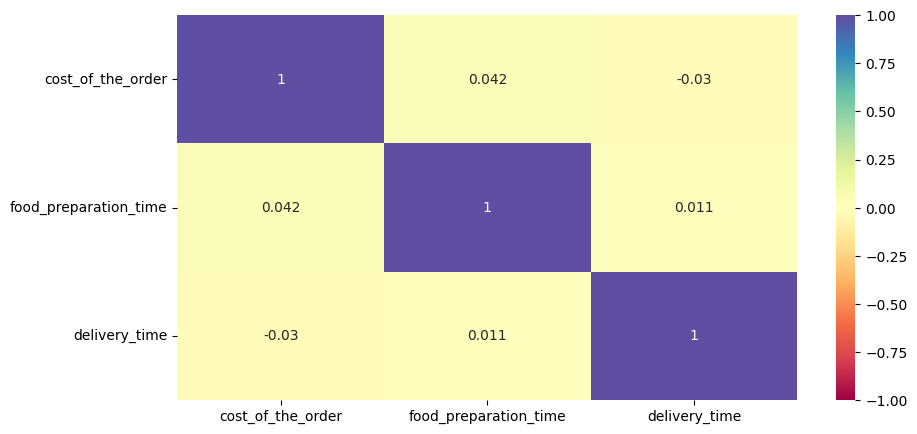

```python
# Set the figure size for the plot to ensure it's large enough to be easily
# readable.
plt.figure(figsize = (10, 5))

# Select only the numeric columns to analyze correlation among them.
numeric_data = df[['cost_of_the_order', 'food_preparation_time',
                   'delivery_time']]

# Compute the correlation matrix for the selected numeric columns.
corr_matrix = numeric_data.corr()

# Create a heatmap to visualize the correlation matrix.
# - annot = True displays the correlation values on the heatmap.
# - cmap = 'Spectral' specifies the color pallete, with colors ranging from
#          blue to red.
# - vmin and vmax set the color scale from -1 to 1, representing the full
#   full range of possible correlations.
sns.heatmap(corr_matrix, annot = True, cmap = 'Spectral', vmin = -1, vmax = 1)

# Display the plot.
plt.show()
```

#### Observations:

- All variables show very low correlation values with each other, suggesting that cost of the order, food preparation time, and delivery time are largely independant of one another.

### Numerical vs Categorical Variables

```python
def anova_test(data, numerical_var, *categorical_vars):

    results = {}

    for cat_var in categorical_vars:
        """
        Perform an ANOVA test and create boxplots for each categorical variable.

        Parameters:
        - data (DataFrame): The DataFrame containing the data.
        - numerical_var (str): Name of the numerical variable.
        - *categorical_vars (str): Names of the categorical variables.
        """

        # Create groups for ANOVA test
        groups = [data[numerical_var][data[cat_var] == level].dropna()
        for level in data[cat_var].unique()]

        # Perform ANOVA
        f_stat, p_value = f_oneway(*groups)

        # Store results
        results[cat_var] = {
            'F-statistic': f_stat,
            'p-value': p_value
        }

        # Generate box plot
        colors = ['skyblue', 'salmon', 'orange', 'lightgreen', 'gold']
        random_color = random.choice(colors)

        plt.figure(figsize = (10, 6))
        sns.boxplot(
            x = numerical_var,
            y = cat_var,
            data = data,
            color = random_color
        )
        plt.title(f"Box Plot of {numerical_var} by {cat_var}")
        plt.xlabel(numerical_var)
        plt.ylabel(cat_var)
        plt.xticks(rotation = 0)
        plt.show()

        # Output results
        print(
            f"ANOVA test for {numerical_var} and {cat_var}:\n"
            f"F-Statistic: {f_stat:.4f}\n"
            f"P-Value: {p_value:.4f}\n"
        )

        if p_value < 0.05:
            print(
                f"There is a statistically significant difference "
                f"between {numerical_var} and {cat_var} (p < 0.05).\n"
            )
        else:
            print(
                f"There is no statistically significant difference "
                f"between {numerical_var} and {cat_var} (p < 0.05).\n"
            )
```

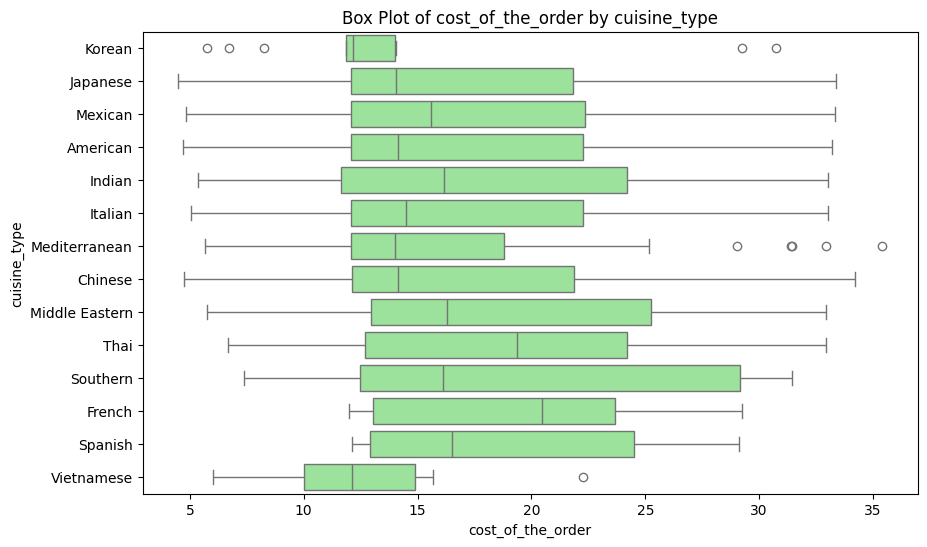

```
ANOVA test for cost_of_the_order and cuisine_type:
F-Statistic: 1.5188
P-Value: 0.1030

There is no statistically significant difference between cost_of_the_order and cuisine_type (p < 0.05).
```

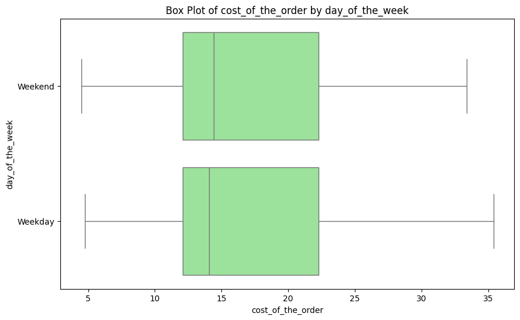

```
ANOVA test for cost_of_the_order and day_of_the_week:
F-Statistic: 0.4831
P-Value: 0.4871

There is no statistically significant difference between cost_of_the_order and day_of_the_week (p < 0.05).
```

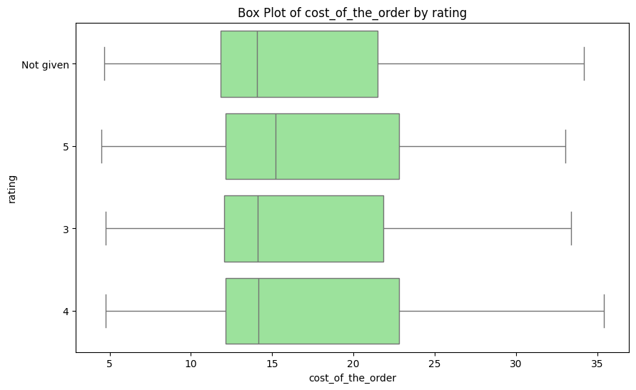

```
ANOVA test for cost_of_the_order and rating:
F-Statistic: 1.7013
P-Value: 0.1647

There is no statistically significant difference between cost_of_the_order and rating (p < 0.05).
```

```python
anova_test(df, 'cost_of_the_order', 'cuisine_type', 'day_of_the_week', 'rating')
```

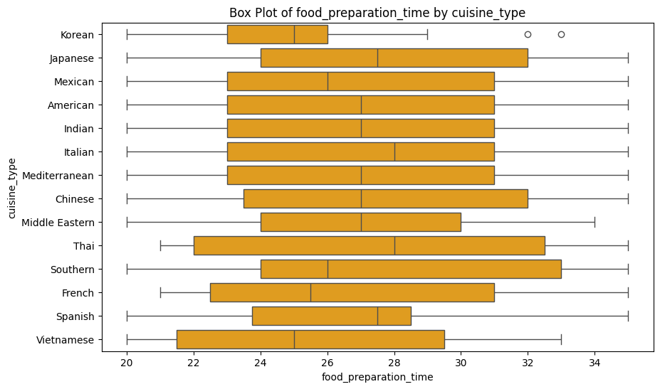

```
ANOVA test for food_preparation_time and cuisine_type:
F-Statistic: 0.5760
P-Value: 0.8749

There is no statistically significant difference between food_preparation_time and cuisine_type (p < 0.05).
```

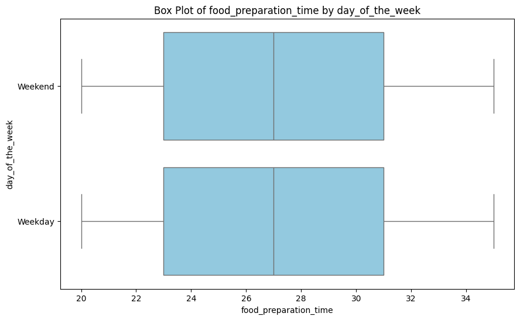

```
ANOVA test for food_preparation_time and day_of_the_week:
F-Statistic: 0.9156
P-Value: 0.3388

There is no statistically significant difference between food_preparation_time and day_of_the_week (p < 0.05).
```

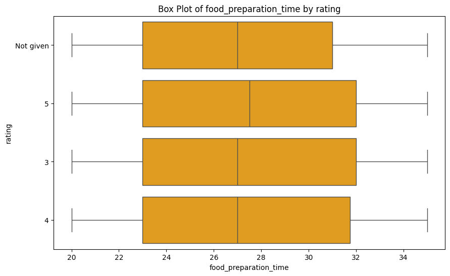

```
ANOVA test for food_preparation_time and rating:
F-Statistic: 0.0186
P-Value: 0.9965

There is no statistically significant difference between food_preparation_time and rating (p < 0.05).
```

```python
anova_test(df, 'food_preparation_time', 'cuisine_type', 'day_of_the_week', 'rating')
```

#### Observations:

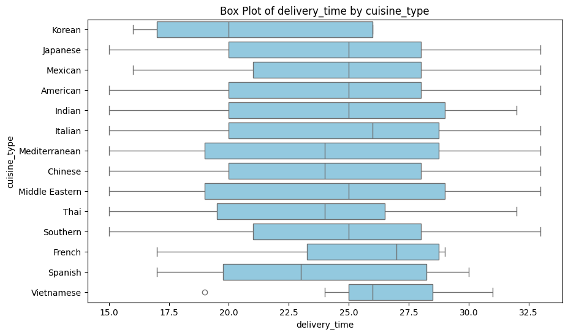

```
ANOVA test for delivery_time and cuisine_type:
F-Statistic: 0.9527
P-Value: 0.4967

There is no statistically significant difference between delivery_time and cuisine_type (p < 0.05).
```

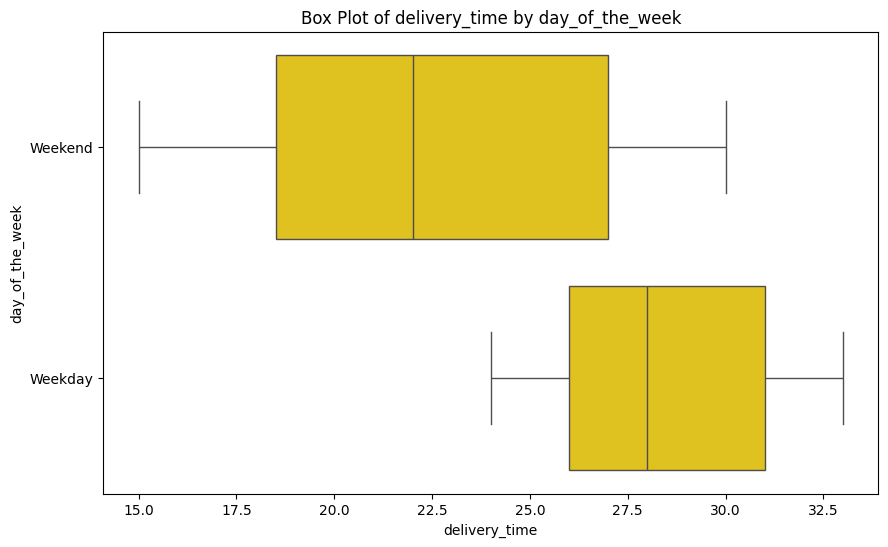

```
ANOVA test for delivery_time and day_of_the_week:
F-Statistic: 759.5061
P-Value: 0.0000

There is a statistically significant difference between delivery_time and day_of_the_week (p < 0.05).
```

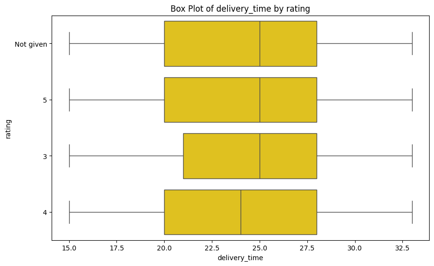

```
ANOVA test for delivery_time and rating:
F-Statistic: 0.8701
P-Value: 0.4559

There is no statistically significant difference between delivery_time and rating (p < 0.05).
```

```python
anova_test(df, 'delivery_time', 'cuisine_type', 'day_of_the_week', 'rating')
```

#### Observations:

1. Delivery Time by Cuisine Type
- The box plot shows variability in the delivery times across different cuisine types, with the Korean cuisine having shorter delivery times.
- The ANOVA test indicates no statistically significant difference in the delivery time across different cuisine types, with a p-value of 0.4967, which is greater than the significance level of 0.05.
2. Delivery Time by Day of the Week
- The box plot shows longer delivery times on weekdays compared to weekends.
- The ANOVA test indicates a statistically significant difference in the delivery time between weekdays and weekends, with a p-value of 0.0000, which is less than the significance level of 0.05.
3. Delivery Time by Rating
- The box plot shows similar median and range values across different ratings.
- The ANOVA test indicates no statistically significant difference in the delivery time across ratings, with a p-value of 0.4559, which is greater than the significance level of 0.05.

### **Question 13:** The company wants to provide a promotional offer in the advertisement of the restaurants. The condition to get the offer is that the restaurants must have a rating count of more than 50 and the average rating should be greater than 4. Find the restaurants fulfilling the criteria to get the promotional offer. [3 marks]

```python
# Convert the 'rating' column to a numeric type, setting non-numeric values to
# NaN (missing values).
df['rating'] = pd.to_numeric(df['rating'], errors = 'coerce')

# Group the DataFrame by 'restaurant_name' and calculate the count and mean of
# ratings for each restaurant.
# Reset the index to turn the grouped object back into a DataFrame.
restaurants = df.groupby('restaurant_name')['rating'] \
                  .agg(['count', 'mean']).reset_index()

# Round the 'mean' rating to two decimal places.
restaurants['mean'] = restaurants['mean'].round(2)

# Filter restaurants that have more than 50 ratings and an average rating
# above 4. These restaurants are selected for a promotional offer.
promo_offer = restaurants[
    (restaurants['count'] > 50) & (restaurants['mean'] > 4)
]

# Sort the filtered DataFrame by the 'mean' ratings in descending order.
promo_offer = promo_offer.sort_values(by = 'mean', ascending = False) \
              .reset_index(drop = True)

# Display the filtered DataFrame with restaurants eligible for the promo offer.
promo_offer
```

|  | restaurant_name | count | mean |
| --- | --- | --- | --- |
| 0 | The Meatball Shop | 84 | 4.51 |
| 1 | Blue Ribbon Fried Chicken | 64 | 4.33 |
| 2 | Shake Shack | 133 | 4.28 |
| 3 | Blue Ribbon Sushi | 73 | 4.22 |

#### Observations:

The following restaurants meet the criteria for the promotional offer (more than 50 ratings and an average rating greater than 4):

1. The Meatball Shop: 4.51 average rating from 84 ratings.
2. Blue Ribbon Fried Chicken: 4.33 average rating from 64 ratings.
3. Shake Shack: 4.28 average rating from 133 ratings.
4. Blue Ribbon Sushi: 4.22 average rating from 73 ratings.

### **Question 14:** The company charges the restaurant 25% on the orders having cost greater than 20 dollars and 15% on the orders having cost greater than 5 dollars. Find the net revenue generated by the company across all orders. [3 marks]

```python
# Identify orders where the cost of the order is greater than $20
orders_gt_20 = (df['cost_of_the_order'] > 20)

# Identify orders where the cost of the order is greater than $5 and less than
# or equal to $20.
orders_gt_5_lte_20 = (df['cost_of_the_order'] > 5) & \
                     (df['cost_of_the_order'] <= 20)

# Calculate the total cost of all orders where the cost is greater than $20.
total_cost_gt_20 = df[orders_gt_20]['cost_of_the_order'].sum()

# Calculate the total cost of all orders where the cost is greater than $5 and
# less than or equal to #20
total_cost_gt_5_lte_20 = df[orders_gt_5_lte_20]['cost_of_the_order'].sum()

# Calculate the net revenue for the company:
# - 25% of the total cost for orders greater than $20.
# - 15% of the total cost for orders greater than $5 and less than or
#   equal to $20.
net_revenue = (total_cost_gt_20 * 0.25) + (total_cost_gt_5_lte_20 * 0.15)

# Print the net revenue, formatted to two decimal places.
print(f"Net revenue: ${net_revenue:.2f}")
```

```
Net revenue: $6166.30
```

#### Observations:

- FoodHub generated a net revenue of 6,166.30 dollars by applying a 25% commission on orders over 20 dollars and a 15% commission on orders over 5 dollars.

### **Question 15:** The company wants to analyze the total time required to deliver the food. What percentage of orders take more than 60 minutes to get delivered from the time the order is placed? (The food has to be prepared and then delivered.) [2 marks]

```python
# Calculate the total time for each order by adding food preparation time and
# delivery time.
df['total_time'] = df['food_preparation_time'] + df['delivery_time']

# Create a boolean Series identifying orders with a total time greater
# than 60 minutes.
orders_gt_60_min = (df['total_time'] > 60)

# Count the number of orders that are greater than 60 minutes (True) and those
# that are not (False).
count_values = orders_gt_60_min.value_counts()

# Print the percentage of orders that take more than 60 minutes, formatted
# to two decimal places.
percentage = count_values[True] / (count_values[True] + count_values[False])
print(
    f"Percentage of orders that take more than 60 minutes to get delivered "
    f"from the time the order is placed: {(percentage * 100):.2f}%"
)
```

```
Percentage of orders that take more than 60 minutes to get delivered from the time the order is placed: 10.54%
```

#### Observations:

- 10.54% of orders take more than 60 minutes to be delivered from the time the order is placed, including both preparation and delivery time.

### **Question 16:** The company wants to analyze the delivery time of the orders on weekdays and weekends. How does the mean delivery time vary during weekdays and weekends? [2 marks]

```python
# Group the DataFrame by whether the day is a weekend or not,
# then calculate the mean delivery time for each group.
mean_delivery = df.groupby(df['day_of_the_week'] == 'Weekend') \
                ['delivery_time'].mean().reset_index()

# Access the mean delivery time for weekends using iloc[1, 1].
# Since there are only two groups (weekend and weekday), iloc[1, 1]
# corresponds to the weekend (True condition).
mean_weekend_delivery = mean_delivery.iloc[1, 1]

# Access the mean delivery time for weekdays using iloc[0, 1]
# which corresponds to the weekday (False condition).
mean_weekday_delivery = mean_delivery.iloc[0, 1]

# Print the results with formatted output for readability.
print(
    f"Mean weekend delivery time: {mean_weekend_delivery:.2f} minutes.\n"
    f"Mean weekday delivery time: {mean_weekday_delivery:.2f} minutes."
)
```

```
Mean weekend delivery time: 22.47 minutes.
Mean weekday delivery time: 28.34 minutes.
```

#### Observations:

- The mean delivery time on weekends is 22.47 minutes.
- The mean delivery time on weekdays is 28.34 minutes.

### Conclusion and Recommendations

### **Question 17:** What are your conclusions from the analysis? What recommendations would you like to share to help improve the business? (You can use cuisine type and feedback ratings to drive your business recommendations.) [6 marks]

### Conclusions:

- American, Japanese, and Italian cuisines are the most popular, especially on weekends, indicating strong customer preferences for these types.
- A large number of orders have no ratings ("Not given"), but among rated orders, high ratings dominate, suggesting general customer satisfaction.
- Analysis shows that cost, food preparation time, and delivery time are largely independent. Operational changes in one area are unlikely to directly impact the others.
- Orders double on weekends, yet delivery times are notably shorter, indicating efficient handling of the increased demand.

### Recommendations:

- Emphasize popular cuisines (American, Japanese, Italian) in marketing campaigns, particularly on weekends, while also promoting less popular cuisines (Vietnamese, Spanish, Korean) to diversify interest and boost demand.
- Encourage more customers to provide ratings through small incentives, improving feedback quality and enabling menu adjustments based on customer satisfaction.
- Given that most orders fall in the 10 to 20 dollar range, introduce combo deals or promotional offers within this bracket to attract budget-conscious customers.
- Maintain sufficient staffing resources on weekends to sustain the shorter delivery times and manage high order volumes effectively.
- Continue optimizing preparation and delivery processes to ensure that the shorter weekend delivery times are maintained consistently during peak periods.
- Expand popular cuisine options in high-demand areas, and continously track feedback to keep the menu aligned with customer preferences and expectations.

```python
!jupyter nbconvert --to html /content/drive/MyDrive/foodhub_project/borja_python_project.ipynb
```

```
[NbConvertApp] Converting notebook /content/drive/MyDrive/foodhub_project/borja_python_project.ipynb to html
[NbConvertApp] WARNING | Alternative text is missing on 16 image(s).
[NbConvertApp] Writing 966660 bytes to /content/drive/MyDrive/foodhub_project/borja_python_project.html
```